# PCIT-CoS-Waitlist RCT Paper 1: BITSEA Problem

Nancy Briggs

2024-04-29

### BITSEA Problem

Output run on 2024-04-29

Values have been calculated by:

- missing values are: 3, 888, 999, 9999
- sum computed from: pf2, pf3, pf4, pf6, pf7, pf8, pf9, pf11, pf12, pf14, pf16, pf17, pf18, pf21, pf23, pf24, pf26, pf27, pf28, pf30, pf32, pf33, pf34, pf35, pf36, pf37, pf38, pf39, pf40, pf41, pf42

#### Descriptives

| group | time | n | mean | sd | median | min | max |
| --- | --- | --- | --- | --- | --- | --- | --- |
| 1 | 1 | 29 | 17.207 | 8.825 | 16 | 3 | 40 |
| 1 | 2 | 24 | 11.958 | 7.573 | 11 | 1 | 32 |
| 1 | 3 | 18 | 10.889 | 10.029 | 8 | 1 | 41 |
| 2 | 1 | 27 | 18.296 | 7.999 | 17 | 6 | 42 |
| 2 | 2 | 13 | 18.462 | 10.461 | 16 | 9 | 45 |
| 2 | 3 | 5 | 15.200 | 8.044 | 11 | 8 | 27 |
| 3 | 1 | 26 | 15.615 | 6.712 | 16 | 4 | 33 |
| 3 | 2 | 21 | 15.571 | 9.595 | 15 | 2 | 43 |
| 3 | 3 | 0 | NaN | NA | NA | Inf | -Inf |

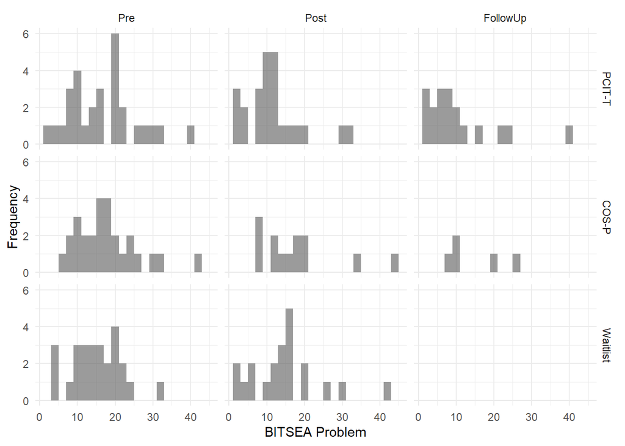

#### Model & Results

A linear mixed model with random effect for individual and fixed effects of group, time and the interaction was run. Estimated marginal means were obtained, and contrasts specified to test Hypothesis 1 and Hypothesis 2.

```
## fixed-effect model matrix is rank deficient so dropping 1 column / coefficient
```

```
## refitting model(s) with ML (instead of REML)
```

|  | Effect | npar | AIC | BIC | logLik | deviance | Chisq | Df | Pr(>Chisq) |
| --- | --- | --- | --- | --- | --- | --- | --- | --- | --- |
| result0 | Intercept | 3 | 1119.547 | 1128.828 | -556.774 | 1113.547 | NA | NA | NA |
| result1 | Group | 5 | 1120.318 | 1135.787 | -555.159 | 1110.318 | 3.229 | 2 | 0.199 |
| result2 | Time | 7 | 1104.621 | 1126.277 | -545.310 | 1090.621 | 19.697 | 2 | 0.000 |
| result3 | Group*Time | 10 | 1102.103 | 1133.041 | -541.052 | 1082.103 | 8.518 | 3 | 0.036 |

This is the ANOVA table for the model. p-values are likelihood ratio tests for adding the new term to the model just before. A p-value <0.05 indicates that adding that term results in better model fit. The most important p-value is the interaction p-value. Here, there is evidence that the pattern of change over time is different among the groups (p=0.036).

```r
summary(result3)
```

```
## Linear mixed model fit by REML. t-tests use Satterthwaite's method [
## lmerModLmerTest]
## Formula: outcome ~ group * time + (1 | id)
##    Data: dat
##
## REML criterion at convergence: 1061
##
## Scaled residuals:
##      Min       1Q   Median       3Q      Max
## -1.58049 -0.45499 -0.02134  0.38839  2.60989
##
## Random effects:
##  Groups   Name        Variance Std.Dev.
##  id       (Intercept) 53.45    7.311
##  Residual             18.42    4.292
## Number of obs: 163, groups:  id, 83
##
## Fixed effects:
##              Estimate Std. Error       df t value Pr(>|t|)
## (Intercept)   17.2069     1.5742  98.9605  10.931  < 2e-16 ***
## group2         1.0894     2.2671  98.9605   0.481   0.6319
## group3        -0.8096     2.2772 100.2349  -0.356   0.7229
## time2         -5.4046     1.2252  79.1128  -4.411 3.21e-05 ***
## time3         -6.5747     1.3660  80.1195  -4.813 6.89e-06 ***
## group2:time2   4.3600     2.0363  83.5735   2.141   0.0352 *
## group3:time2   4.6714     1.8091  80.3350   2.582   0.0116 *
## group2:time3   3.4562     2.7830  83.9518   1.242   0.2177
## ---
## Signif. codes:  0 '***' 0.001 '**' 0.01 '*' 0.05 '.' 0.1 ' ' 1
##
## Correlation of Fixed Effects:
##             (Intr) group2 group3 time2  time3  grp2:2 grp3:2
## group2      -0.694
## group3      -0.691  0.480
## time2       -0.329  0.229  0.228
## time3       -0.295  0.205  0.204  0.438
## group2:tim2  0.198 -0.285 -0.137 -0.602 -0.264
## group3:tim2  0.223 -0.155 -0.333 -0.677 -0.297  0.407
## group2:tim3  0.145 -0.209 -0.100 -0.215 -0.491  0.346  0.146
## fit warnings:
## fixed-effect model matrix is rank deficient so dropping 1 column / coefficient
```

#### Estimated Means & Change

Estimated means for each Treatment and Time are presented. In addition, within-group change between time points is presented with 95% CIs.

##### Group mean difference at each timepoint

Effect sizes all calculated by the pooled T1 SD of the outcome. Adjusted p-value from Bonferroni correction.

Group Differences at Each Time Point

[output not shown]

* Effect size scaled by pooled T1 SD  
† ES 95% Bootstrapped Percentile CI limits  
‡ If you want a positive ES (and it is calculated as negative), be sure to switch the signs and positions of the lower and upper CIs.

##### Change within each group

Within-Group Change and Effect Sizes

[output not shown]

* Effect size scaled by pooled T1 SD  
† ES 95% Bootstrapped Percentile CI limits  
‡ If you want a positive ES (and it is calculated as negative), be sure to switch the signs and positions of the lower and upper CIs.

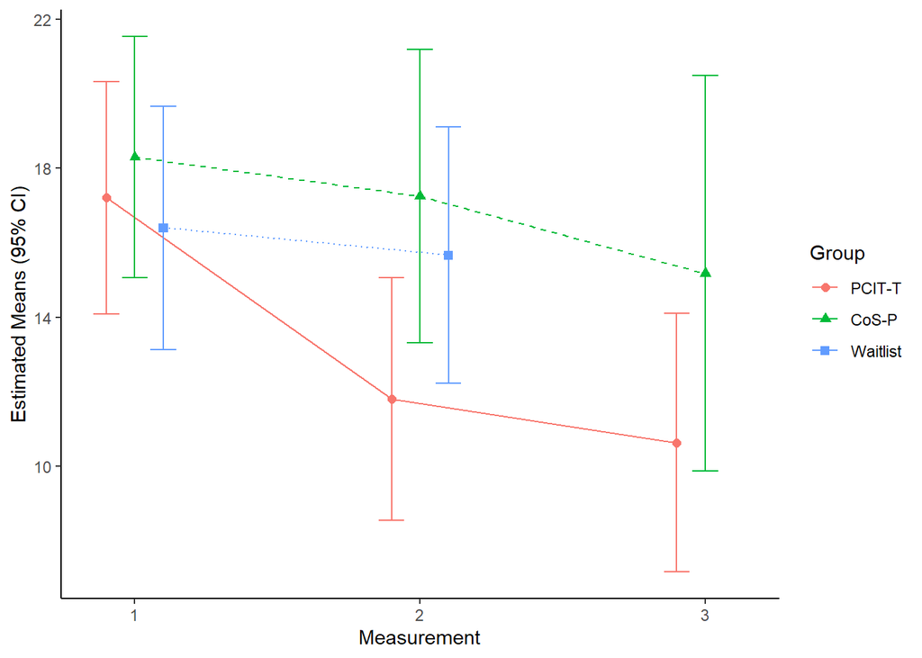

#### Hypothesis 1

We hypothesize that from baseline (‘T1’) to post-treatment/waitlist (‘T2’) there will be a gradient effect, whereby parent-child dyads who receive PCIT-T will show the greatest gains and parent-child dyads who receive no treatment will show the least gains. For the outcome, then, the null hypothesis is:

$H_0: \text {mean change}(\text{PCIT-T}) = \text {mean change}(\text{CoS-P}) = \text {mean change}(\text{Waitlist})$ $H_A: \text {mean change}(\text{PCIT-T}) > \text {mean change}(\text{CoS-P}) > \text {mean change}(\text{Waitlist})$

This is a joint hypothesis test.

First, confirming that the ordering of the means is as hypothesized:

```
## group = 1:
##  contrast estimate   SE   df t.ratio p.value
##  1 - 2       5.405 1.23 78.5   4.407  0.0001
##  1 - 3       6.575 1.37 79.6   4.807  <.0001
##  2 - 3       1.170 1.38 77.0   0.848  0.6742
##
## group = 2:
##  contrast estimate   SE   df t.ratio p.value
##  1 - 2       1.045 1.63 85.7   0.640  0.7983
##  1 - 3       3.118 2.43 84.6   1.282  0.4089
##  2 - 3       2.074 2.47 79.8   0.841  0.6790
##
## group = 3:
##  contrast estimate   SE   df t.ratio p.value
##  1 - 2       0.733 1.33 80.8   0.550  0.8468
##  1 - 3      nonEst   NA   NA      NA      NA
##  2 - 3      nonEst   NA   NA      NA      NA
##
## Degrees-of-freedom method: kenward-roger
## P value adjustment: tukey method for comparing a family of 3 estimates
```

| contrast | group | t1t2change | quality | p.value |
| --- | --- | --- | --- | --- |
| 1 - 2 | 1 | -5.405 | decreased t1 to t2 | 0.000 |
| 1 - 2 | 2 | -1.045 | decreased t1 to t2 | 0.798 |
| 1 - 2 | 3 | -0.733 | decreased t1 to t2 | 0.847 |

Is the ordering of change satisfied?

Note that I interpreted an increase in scores as being “better”. If a decrease in scores is “better” then these change values should be interpreted in that light.

```
##   (Intercept) group2 group3 time2 time3 group2:time2 group3:time2 group2:time3
## 1           0      0      0     0     0            1            0            0
## 2           0      0      0     0     0           -1            1            0
```

```
##
##   General Linear Hypotheses
##
## Linear Hypotheses:
##        Estimate
## 1 == 0   4.3600
## 2 == 0   0.3114
##
## Global Test:
##       F DF1 DF2  Pr(>F)
## 1 4.045   2 153 0.01942
```

p= 0.019. We have evidence that there is a difference in the change over from Baseline to Post amongst the groups.

#### Hypothesis 2

##### Change from T2-T3

There will be a gradient of size of change from T2 to T3 such that the change in the PCIT-T group > the change in the CoS-P group. This isn’t really a gradient; it’s just 1 hypothesis.

First, the change in PCITT and COSP from time 2 to time 3:

```
## group = 1:
##  time emmean   SE    df lower.CL upper.CL
##  1      17.2 1.57  98.4    14.08     20.3
##  2      11.8 1.65 111.1     8.54     15.1
##  3      10.6 1.75 129.4     7.16     14.1
##
## group = 2:
##  time emmean   SE    df lower.CL upper.CL
##  1      18.3 1.63  98.4    15.06     21.5
##  2      17.3 1.99 144.9    13.32     21.2
##  3      15.2 2.69 144.4     9.87     20.5
##
## group = 3:
##  time emmean   SE    df lower.CL upper.CL
##  1      16.4 1.65 100.9    13.13     19.7
##  2      15.7 1.73 115.4    12.23     19.1
##  3    nonEst   NA    NA       NA       NA
##
## Degrees-of-freedom method: kenward-roger
## Confidence level used: 0.95
```

```
## group = 1:
##  contrast estimate   SE   df lower.CL upper.CL
##  1 - 2       5.405 1.23 78.5     2.47     8.33
##  1 - 3       6.575 1.37 79.6     3.31     9.84
##  2 - 3       1.170 1.38 77.0    -2.13     4.47
##
## group = 2:
##  contrast estimate   SE   df lower.CL upper.CL
##  1 - 2       1.045 1.63 85.7    -2.85     4.94
##  1 - 3       3.118 2.43 84.6    -2.68     8.92
##  2 - 3       2.074 2.47 79.8    -3.82     7.97
##
## group = 3:
##  contrast estimate   SE   df lower.CL upper.CL
##  1 - 2       0.733 1.33 80.8    -2.45     3.92
##  1 - 3      nonEst   NA   NA       NA       NA
##  2 - 3      nonEst   NA   NA       NA       NA
##
## Degrees-of-freedom method: kenward-roger
## Confidence level used: 0.95
## Conf-level adjustment: tukey method for comparing a family of 3 estimates
```

```r
## Specify contrast matrices
# Hyp1 is 1 df test
# could use alternative="less" ir alternative="greater" in glht
hyp2   <- matrix(c(0, 0,0, 0,0, -1,0,1 ),1)
hyp2F <- glht(result3, linfct = hyp2)
summary(hyp2F)
```

```
##
##   Simultaneous Tests for General Linear Hypotheses
##
## Fit: lmer(formula = outcome ~ group * time + (1 | id), data = dat)
##
## Linear Hypotheses:
##        Estimate Std. Error z value Pr(>|z|)
## 1 == 0  -0.9037     2.8227   -0.32    0.749
## (Adjusted p values reported -- single-step method)
```

```r
s<-summary(hyp2F, test = Ftest())
#also see this webpage for more on contrasts https://rcompanion.org/rcompanion/h_01.html



## Extract pvaue for evidence / no evidence
evidence = ifelse(s$test$pvalue<0.05, "evidence", "no evidence")
```

Change in G1 from T2 to T3: 1.17

Change in G2 from T2 to T3: 2.074

##### Change from T1-T3

```
##
##   General Linear Hypotheses
##
## Linear Hypotheses:
##        Estimate
## 1 == 0    3.456
##
## Global Test:
##       F DF1 DF2 Pr(>F)
## 1 1.542   1 153 0.2162
```

Change in G1 from T1 to T3: 6.575

Change in G2 from T1 to T3: 3.118

p=0.2162. We have no evidence that the change from T1 to T3 is different for G1 and G2

#### Residuals

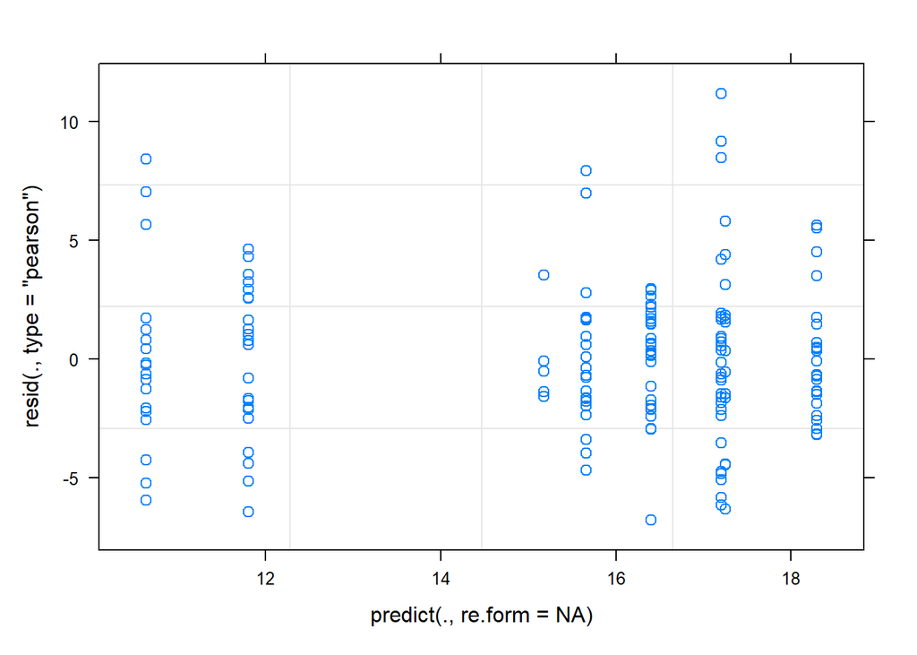

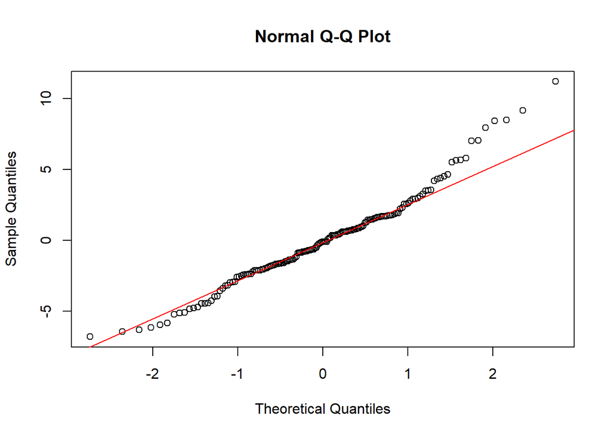

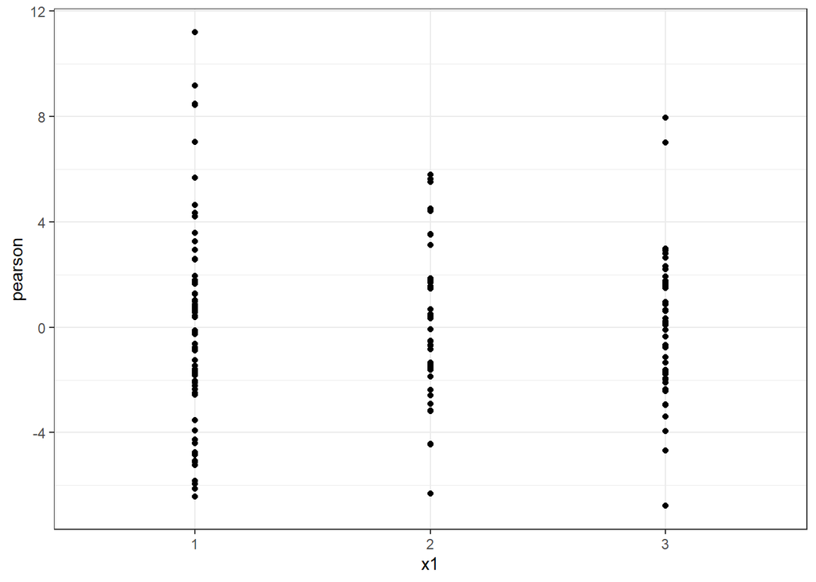

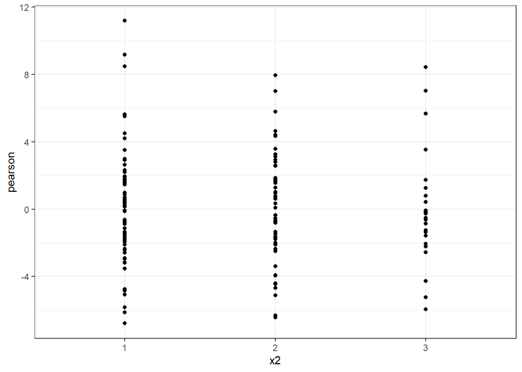

```r
rm(list = ls())
```